# Logboek: Publieke Opinie

Floris Menninga

2024-04-22

```r
# Libraries
library(data.tree)
library(ggraph)
library(igraph)
library(tidyverse)
library(viridis)
library(ggplot2)
library(dplyr)
library(rgexf)
library(ggrepel)
# Voor statistische analyses:
library("pwr")
```

## **Inleiding:**

Vragen over het abortus beleid zijn polariserende ethische kwesties. In ons onderzoek trachten we correlaties te vinden tussen verschillende variabelen zoals: leeftijd, geslacht, opleidingsniveau, geloof etc. en de ideologische verschillen in mening tussen deze mensen.

Om de meningen van het publiek te peilen met betrekking tot hun ethische normen en waarden is er een vragenlijst opgesteld die de volgende vragen en stellingen bevat:

#### Persoonlijke vragen:

Wat is uw geslacht?

Man, Vrouw, Anders, Zeg ik liever niet.

Wat is uw leeftijd? (Jaar)

Bent u gelovig? (Ja/nee)

Zo ja welke geloof? Christendom, Islam, Hindoeïsme, Boeddhisme, jodendom, anders: ___

Waar bent u geboren? (Land)

In Nederland? –> welke provincie?

#### Inhoudelijke vragen:

1. Vindt u dat iemand zelf moet kunnen kiezen of die een abortus wil?

1.5 Zo nee, zijn er situaties waarin dit wel het geval moet zijn?

2. Moet een kind (onder 18) de keuze hebben om een abortus te krijgen?

2.5 Moeten ouders zeggenschap hebben over of hun kind wel of niet abortus mogen plegen.

https://fiom.nl/ongewenst-zwanger/abortus/wet-regelgeving-abortus

3. Is adoptie een alternatief voor abortus?
4. Moet de bedenktijd terugkomen?

5.. Vindt u dat er abortus gepleegd mag worden als de gezondheid van de vrouw door de zwangerschap in gevaar kan komen?

6. Vindt u dat er abortus gepleegd mag worden als de zwangerschap een gevolg is van verkrachting?
7. Moet het wettelijk verplicht voor vrouwen die een abortus willen om een echo van de foetus te zien voor een abortus toegestaan is?
8. Moet de vader zeggenschap hebben over de beslissing om een abortus te induceren?

Een abortus is wenselijk wanneer:

```
Het leven van de vrouw in gevaar is: (0 tot 10)

Het kind met een geestelijke handicap (zoals het syndroom van Down) geboren zou worden. (0 tot 10)

Het kind met een levensbedreigende ziekte geboren zou worden. (0 tot 10)

De zwangerschap veroorzaakt was door verkrachting. (0 tot 10)

De vrouw het kind niet wil hebben voor niet gespecificeerde redenen.
```

Enkele vragen hiervan zijn afgeleid van het volgende document: https://news.gallup.com/poll/1576/abortion.aspx

De enquête is vervolgens in Microsoft Forms gemaakt met de bovenstaande vragen.

## **Automatisch gegenereerde testdata**

Voordat de data van de enquete verzameld was hebben we testdata gemaakt met behulp van R. Dit heeft als doel om te oefenen met de gebruikte statistische analyse methoden die ook gebruikt gaan worden voor echte data.

## Verspreiden van de enquete

```r
abortus <- read.csv("abortus_dataset.csv",
                    na.strings = "NA")
head(abortus)
```

```
##   ID       Begintijd Tijd.van.voltooien    E.mail Naam
## 1  1  5-8-24 8:49:29     5-8-24 8:51:35 anonymous   NA
## 2  2  5-8-24 8:49:07     5-8-24 8:52:43 anonymous   NA
## 3  3  5-8-24 8:50:36     5-8-24 8:53:12 anonymous   NA
## 4  4  5-8-24 9:09:33     5-8-24 9:11:26 anonymous   NA
## 5  5 5-8-24 10:01:09    5-8-24 10:03:33 anonymous   NA
## 6  6 5-8-24 10:07:21    5-8-24 10:10:00 anonymous   NA
##   Tijd.van.laatste.wijziging Wat.is.uw.geslacht..
## 1                         NA                  Man
## 2                         NA                  Man
## 3                         NA                Vrouw
## 4                         NA                  Man
## 5                         NA                Vrouw
## 6                         NA                Vrouw
##   Wat.is.het.hoogste.onderwijsniveau.dat.u.heeft.afgerond. Wat.is.uw.leeftijd.
```

[output cut: 139 more lines]

```r
summary(abortus)
```

```
##        ID       Begintijd         Tijd.van.voltooien    E.mail
##  Min.   :  1   Length:109         Length:109         Length:109
##  1st Qu.: 28   Class :character   Class :character   Class :character
##  Median : 55   Mode  :character   Mode  :character   Mode  :character
##  Mean   : 55
##  3rd Qu.: 82
##  Max.   :109
##    Naam         Tijd.van.laatste.wijziging Wat.is.uw.geslacht..
##  Mode:logical   Mode:logical               Length:109
##  NA's:109       NA's:109                   Class :character
##                                            Mode  :character
##
##
##
##  Wat.is.het.hoogste.onderwijsniveau.dat.u.heeft.afgerond. Wat.is.uw.leeftijd.
##  Length:109                                               Min.   :15.00
##  Class :character                                         1st Qu.:22.00
##  Mode  :character                                         Median :46.00
##                                                           Mean   :41.38
##                                                           3rd Qu.:54.00
##                                                           Max.   :80.00
##  Wat.is.uw.religieuze.overtuiging..
##  Length:109
##  Class :character
##  Mode  :character
##
##
##
##  In.welke.provincie.heeft.u.het.grootste.deel.van.uw.jeugd.doorgebracht.
##  Length:109
##  Class :character
##  Mode  :character
##
##
##
##  Vindt.u.dat.iemand.zelf.moet.kunnen.kiezen.of.die.een.abortus.wil.
##  Length:109
##  Class :character
##  Mode  :character
##
```

[output cut: 99 more lines]

```
##
##  De.vrouw.niet.in.staat.is.voor.het.kind.te.zorgen.vanwege.financiële.beperkingen
##  Length:109
##  Class :character
##  Mode  :character
##
##
##
##  Wil.je.nog.iets.kwijt.over.de.vragen.of.iets.toevoegen.
##  Length:109
##  Class :character
##  Mode  :character
##
##
##
```

```r
#str(abortus)
```

[figure not shown]

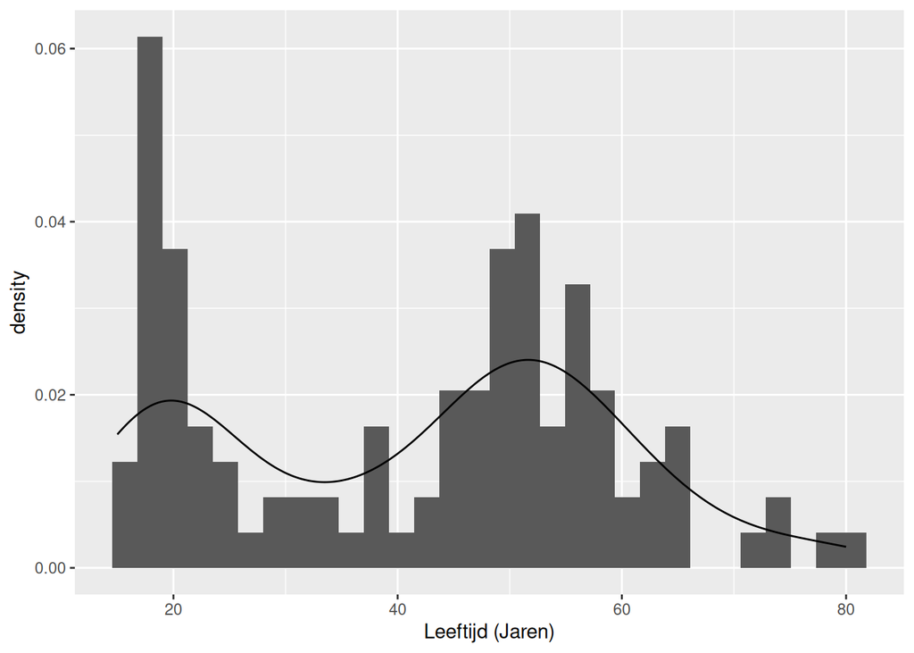

```r
df_leeftijd <- data.frame(abortus$Wat.is.uw.leeftijd.)

# verdeling van de leeftijden:
ggplot(df_leeftijd, aes(x= abortus$Wat.is.uw.leeftijd.)) +
  geom_histogram(aes(y = ..density..)) +
  geom_density() +
  xlab("Leeftijd (Jaren)")
```